# Project2

Grace Nguyen

2022-11-14

## **1. Introduction**

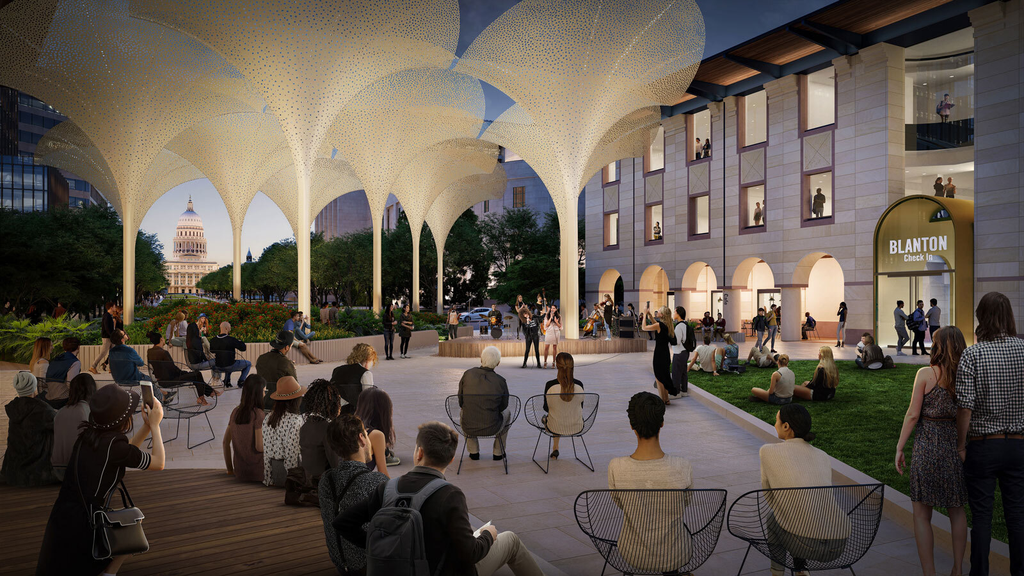

(Image Courtesy of the Blanton Museum)

Pictured above is a digital rendering of UT’s own Blanton Museum, or at least what it’s supposed to look like in the near future. As the city of Austin and University revitalize their facilities to match the pace of the city’s robust growth and evolve alongside UT’s student population, student encounters with construction at and around UT are not only inevitable, but also a part of daily life.

In this report we will analyze the apportionment of combined public and private construction spending to various sectors. To do so, we will utilize the [Construction Spending Dataset](https://corgis-edu.github.io/corgis/csv/construction_spending/) from the [CORGIS Dataset Project](https://corgis-edu.github.io/corgis//). The data was collected from the Value of Construction Put in Place Survey, a monthly survey which began in 1964. This dataset only contains data from January 2002 to January 2016. The survey provides monthly estimates of the total dollar value of construction work done in the U.S., covering construction work done each month on new structures or improvements to existing structures for private and public sectors. Data estimates include the cost of labor and materials, cost of architectural and engineering work, overhead costs, interest and taxes paid during construction, and contractor’s profits. Data collection begins on the first day after the reference month and continues for about three weeks.

## **2. Data Preparation**

After importing the raw CSV file, I removed extraneous variables and consolidated the multiple time variables, of which there were initially 4 separate columns (month, month name, period, and year), into a single date variable. I also removed the extraneous index variable, as R numbers the rows already, making the additional variable unnecessary.

After cleaning up the dataset, I made 2 different subsets, one containing only the 5 variables for univariate analysis, and one subset with those variables along with the date.

## **3. Variable Descriptions**

| Variable | Type | Variable Description |
| --- | --- | --- |
| Commercial | Numeric | Annual Combined Spending on Construction in the Commercial Sector |
| Educational | Numeric | Annual Combined Spending on Construction in the Education Sector |
| Highway and Street | Numeric | Annual Combined Spending on Construction of Highways and Streets |
| Office | Numeric | Annual Combined Spending on Construction of Office Buildings |
| Transportation | Numeric | Annual Combined Spending on Construction in the Transport Sector |
| Year | Date | Year and month in which the data was collected |

## **4. Univariate Analyses**

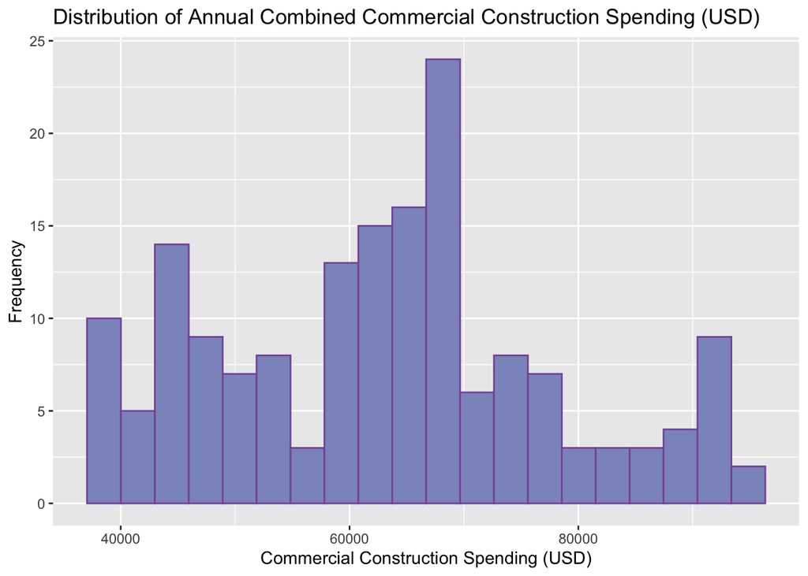

The distribution of Commercial Construction Spending (USD) is relatively unimodal and somewhat symmetric, with a mean of 62988 and a standard deviation of 14795.

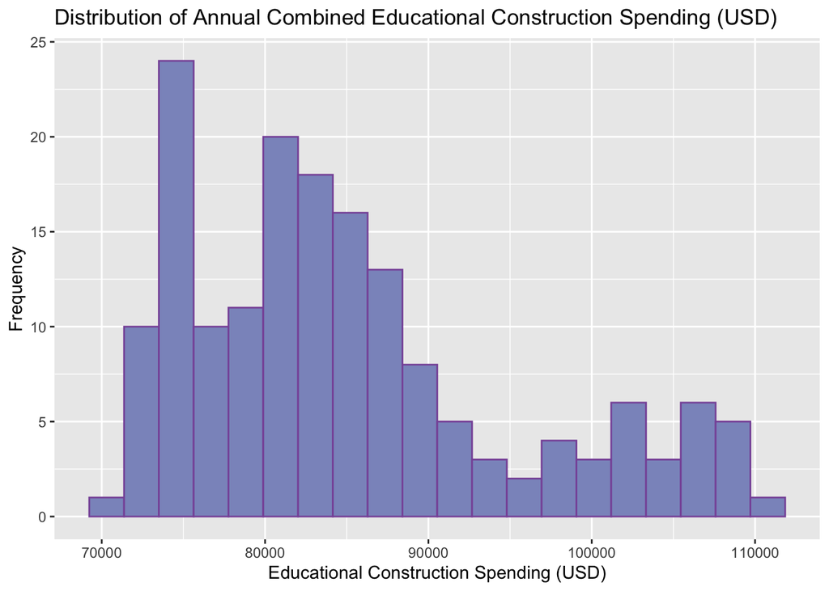

The distribution of Educational Construction Spending (USD) is unimodal and right skewed, with a mean of 83383 and an interquartile range of 11791

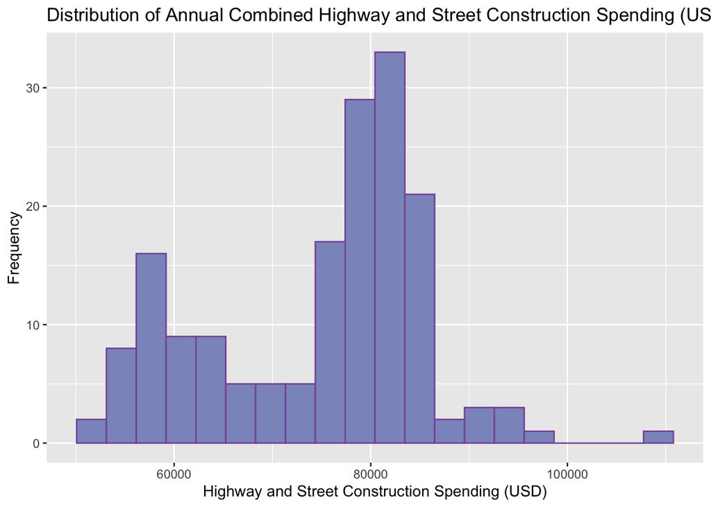

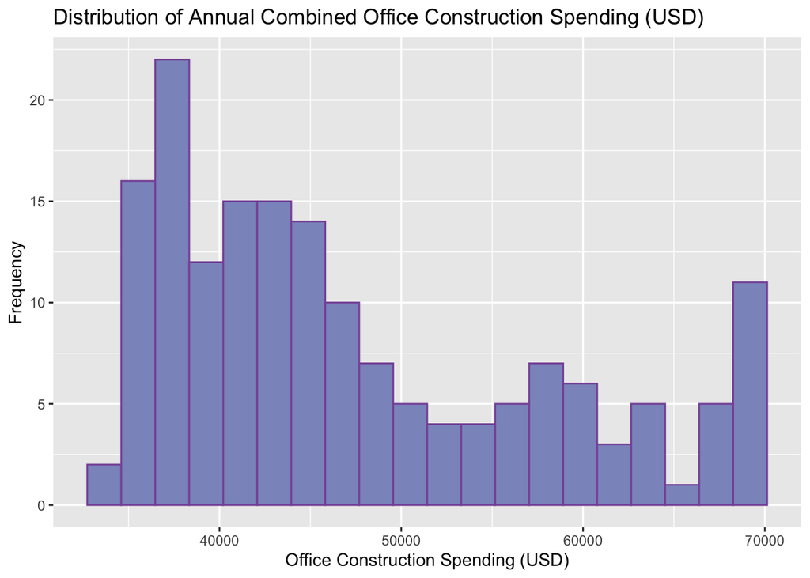

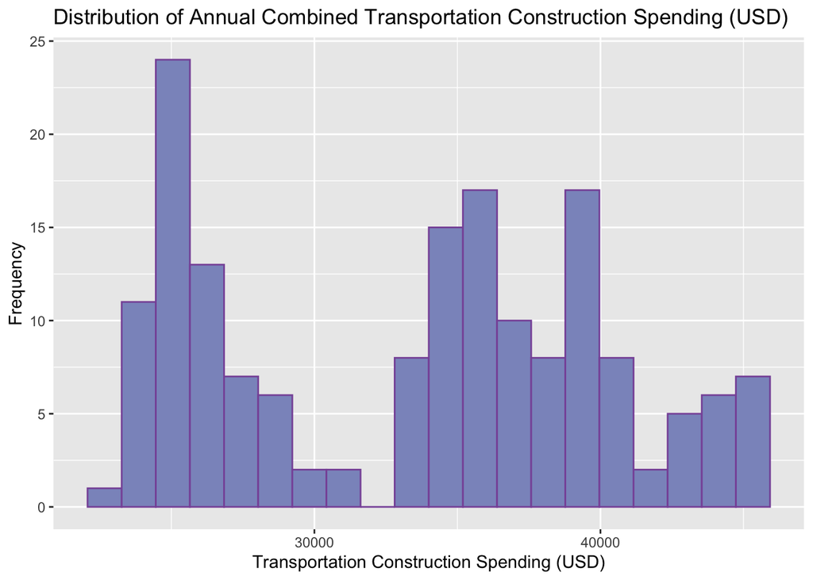

## **5. Multivariate Analyses**

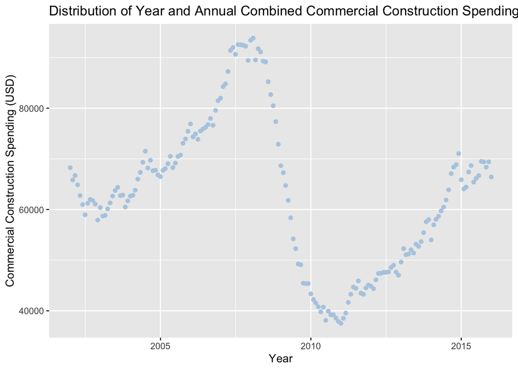

The correlation coefficient between Year and Commercial Construction Spending is -0.332, indicative of a weak negative correlation, meaning that Commercial Construction Spending had a very slight tendency to decrease with time.

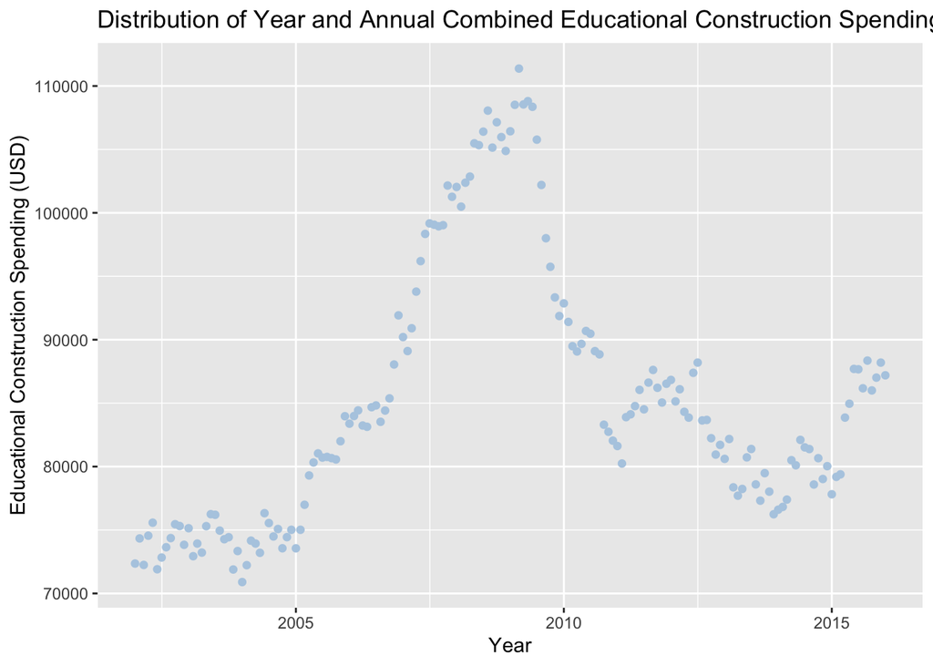

The correlation coefficient between Year and Educational Construction Spending is 0.221, indicative of a weak positive correlation, meaning that Educational Construction Spending had a slight tendency to increase with time.

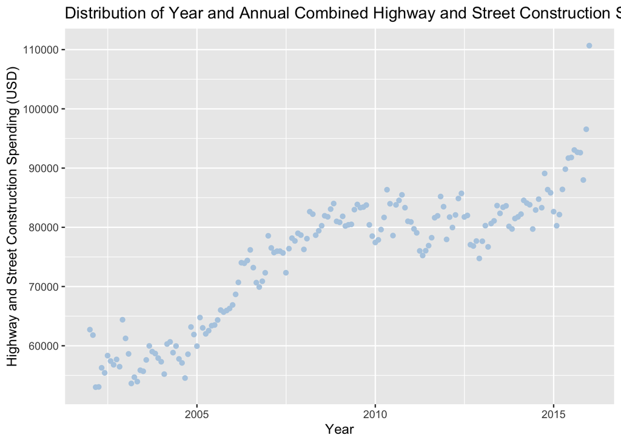

The correlation coefficient between Year and Highway & Street Construction Spending is 0.887, indicative of a strong positive correlation, meaning that Highway and Street Construction Spending has a strong tendency to increase with time.

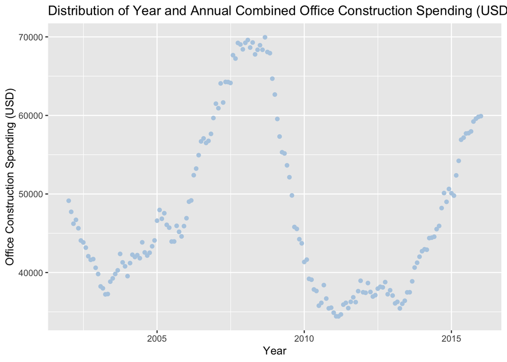

The correlation coefficient between Year and Office Construction Spending is -0.037, indicative of a weak negative correlation, meaning that Office Construction Spending has a slight tendency to decrease with time.

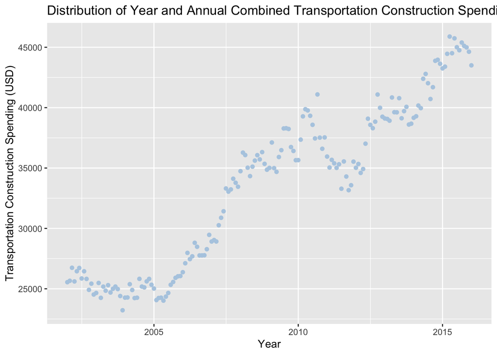

The correlation coefficient between Year and Transportation Construction Spending is 0.945, indicative of a strong positive correlation, meaning that Transportation Construction Spending has a strong tendency to increase with time.

## **6. Reproducibility Resources**

[Project 2 Repository](https://github.com/gracenguyn/SDS313-Project2.git)

The Github repository includes the CSV file for the dataset used in this report, the image file used in the Introduction, the markdown file which I wrote everything in, and the HTML file outputted by the markdown.

## **7. Choice Elements**

In preparing my data, I reshaped (B) and combined various alphanumeric date variables into a single variable, which I then parsed as a date (E). In preparing for multivariate analysis, I created a new variable from my date variable which converted the date vector to numeric so that I could run quantitative analysis. To construct all of my graphs, I created 2 separate functions (J), one for univariate and one for bivariate graphs, which both include an optional argument to create a plot using base r rather than the function default ggplot. I utilized if-statements to include this functionality (I). I also attempted to use a for-loop to loop through my variable calls to the function (H).

## **8. References**

[Construction Spending Dataset](https://corgis-edu.github.io/corgis/csv/construction_spending/)

[CORGIS Dataset Project](https://corgis-edu.github.io/corgis/)

[Image Courtesy of the Blanton Museum of Art](https://blantonmuseum.org/about-the-project/construction-updates/)